```python
# miscellaneous utility
import numpy #numerical processing, incl. data which come in numpy.ndarray
from sklearn.model_selection import train_test_split #randomly separate training and test data
from sklearn.datasets import fetch_openml #retrieve MNIST dataset from internet

# for logistic regression
from sklearn.preprocessing import StandardScaler #standardize data for better performance
import matplotlib.pyplot as plt #plot theta-matrices
from sklearn.linear_model import LogisticRegression #classifier

# for support vector machines
from sklearn.svm import SVC #classifier

# for naive bayes
from sklearn.naive_bayes import * #classifiers
```

# Logistic Regression

Logistic regression uses any one of multiple possible solvers to find a logistic curve of best fit for the given data. This logistic curve is generated by the formula 1/(1+e^-(θ¬TX)), where θ is a vector of weights applied to each feature of an example within data matrix X (with examples m and features n+1). By altering these weights, the linear combination in the exponent of the function can be changed so that its cost function (measuring how inaccurate the regression was) can be minimized.

Logistic regression is adaptable and a good all-around utility. It runs fairly fast, and can usually be reduced to a closed-form linear-algebra-based solution, reducing the overall process time. By including features which are polynomial mutations of other features, sophisticated nonlinear decision boundaries can be formed. This does, however, leave the algorithm open to overfitting, therefore requiring regularization.

The MNIST dataset was loaded from openml.org, then randomly divided into training and testing datasets of 60,000 and 10,000 examples respectively, then standardized for optimal processing efficiency in the logistic regression algorithm. This random partition also means that accuracy varies slightly between runs of the same code.

```python
X, y = fetch_openml("mnist_784", return_X_y = True)
X_train, X_test, y_train, y_test = train_test_split(X, y, train_size = 60000, test_size = 10000)

scaler = StandardScaler()
X_train = scaler.fit_transform(X_train)
X_test = scaler.transform(X_test)
```

High-C runs produced plots which looked like this (this example C=1E9):

*Note: When run in jupyter, an iteration limit exception sometimes occurs. This does not always happen, and does not seem to affect model accuracy.*

```
0.9159
```

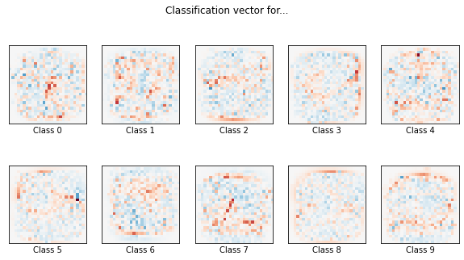

```python
# fit model and output accuracy
classifier = LogisticRegression(C = 10**9, penalty ='l2')
classifier.fit(X_train, y_train)
print(classifier.score(X_test, y_test))

# display colored plot of theta matrix
# code cribbed from scikit-learn.org
coef = classifier.coef_.copy()
plt.figure(figsize=(10, 5))
scale = numpy.abs(coef).max()
for i in range(10):
    l1_plot = plt.subplot(2, 5, i + 1)
    l1_plot.imshow(coef[i].reshape(28, 28), interpolation='nearest',
                   cmap=plt.cm.RdBu, vmin=-scale, vmax=scale)
    l1_plot.set_xticks(())
    l1_plot.set_yticks(())
    l1_plot.set_xlabel('Class %i' % i)
plt.suptitle('Classification vector for...')
```

While low-C runs produced plots which more resembled the digits they were supposed to classify (this example C=0.001):

```
0.9177
```

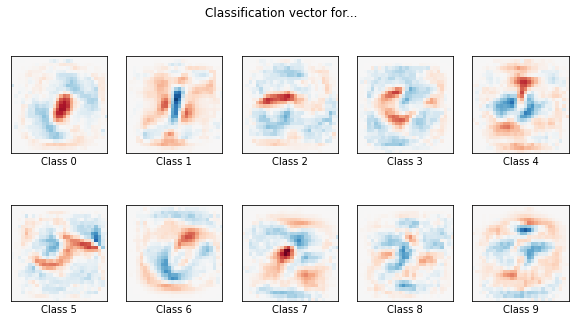

```python
# fit model and output accuracy
classifier = LogisticRegression(C = 0.001, penalty ='l2')
classifier.fit(X_train, y_train)
print(classifier.score(X_test, y_test))

# display colored plot of theta matrix
# code cribbed from scikit-learn.org
coef = classifier.coef_.copy()
plt.figure(figsize=(10, 5))
scale = numpy.abs(coef).max()
for i in range(10):
    l1_plot = plt.subplot(2, 5, i + 1)
    l1_plot.imshow(coef[i].reshape(28, 28), interpolation='nearest',
                   cmap=plt.cm.RdBu, vmin=-scale, vmax=scale)
    l1_plot.set_xticks(())
    l1_plot.set_yticks(())
    l1_plot.set_xlabel('Class %i' % i)
plt.suptitle('Classification vector for...')
```

And on extremely low-C runs, the resemblance between plot and digit is especially strong (this example C=1E-9):

```
0.1129
```

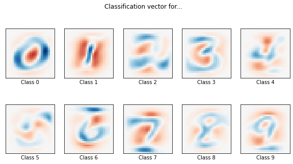

```python
# fit model and output accuracy
classifier = LogisticRegression(C = 10**-9, penalty ='l2')
classifier.fit(X_train, y_train)
print(classifier.score(X_test, y_test))

# display colored plot of theta matrix
# code cribbed from scikit-learn.org
coef = classifier.coef_.copy()
plt.figure(figsize=(10, 5))
scale = numpy.abs(coef).max()
for i in range(10):
    l1_plot = plt.subplot(2, 5, i + 1)
    l1_plot.imshow(coef[i].reshape(28, 28), interpolation='nearest',
                   cmap=plt.cm.RdBu, vmin=-scale, vmax=scale)
    l1_plot.set_xticks(())
    l1_plot.set_yticks(())
    l1_plot.set_xlabel('Class %i' % i)
plt.suptitle('Classification vector for...')
```

This at first seemed counterintuitive to me, since a perfect fit of the digit looks like an overfit while a more uniform mess looks like an underfit, but I was thinking about it the wrong way. These pretty pictures which look exactly like their digits are actually showing extremely high bias. The smooth shapes shown in the plot only show the major features of the digits and generalize too much. The pixelated disaster of the high-C plot is actually showing the high variance of an extremely fitted model, and the fact that this didn’t affect the accuracy even when checking against a test dataset of 10,000 images suggests that the variation in the images from the original dataset really is extremely high and a high-variance model is appropriate.

# Support Vector Machines

Support vector machines use some similar principles to logistic regression models, such as a cost function which needs to be minimized and a decision boundary generated at the end. However, they trim a lot of computational fat and make use of a lot of tricks to cut down execution time. When their C-values are set high, they try to create a decision boundary with as much of a data-free margin on either side of it as possible. Since they are so computationally efficient compared to logistic regression, they are good candidates for applying the otherwise computation-heavy concept of kernel functions. When using kernel functions, instead of using the variables in the data as features, the algorithm uses the outputs of a kernel function defining the similarity of each example to each other example as features. By changing the type and bandwidth of this kernel function, different decision boundaries can be achieved.

The MNIST dataset was randomly divided once again into training and testing datasets, but this time of 10,000 and 10,000 examples respectively. This random partition also means that accuracy varies slightly between runs of the same code.

```python
X_train, X_test, y_train, y_test = train_test_split(X, y, train_size = 10000, test_size = 10000)
```

```python
classifier = SVC(kernel = 'linear', C=1000000)
classifier.fit(X_train, y_train)
print(classifier.score(X_test, y_test))
```

```
0.9126
```

```python
classifier = SVC(kernel = 'linear', C=1)
classifier.fit(X_train, y_train)
print(classifier.score(X_test, y_test))
```

```
0.9126
```

```python
classifier = SVC(kernel = 'linear', C=0.000001)
classifier.fit(X_train, y_train)
print(classifier.score(X_test, y_test))
```

```
0.931
```

```python
classifier = SVC(kernel = 'poly', C=1000000, degree=2)
classifier.fit(X_train, y_train)
print(classifier.score(X_test, y_test))
```

```
0.9611
```

```python
classifier = SVC(kernel = 'poly', C=1, degree=2)
classifier.fit(X_train, y_train)
print(classifier.score(X_test, y_test))
```

```
0.9562
```

```python
classifier = SVC(kernel = 'poly', C=0.000001, degree=2)
classifier.fit(X_train, y_train)
print(classifier.score(X_test, y_test))
```

```
0.1147
```

```python
classifier = SVC(kernel = 'poly', C=1000000, degree=3)
classifier.fit(X_train, y_train)
print(classifier.score(X_test, y_test))
```

```
0.9567
```

```python
classifier = SVC(kernel = 'poly', C=1, degree=3)
classifier.fit(X_train, y_train)
print(classifier.score(X_test, y_test))
```

```
0.9524
```

```python
classifier = SVC(kernel = 'poly', C=0.000001, degree=3)
classifier.fit(X_train, y_train)
print(classifier.score(X_test, y_test))
```

```
0.1147
```

```python
classifier = SVC(kernel = 'poly', C=1000000, degree=4)
classifier.fit(X_train, y_train)
print(classifier.score(X_test, y_test))
```

```
0.9455
```

```python
classifier = SVC(kernel = 'poly', C=1, degree=4)
classifier.fit(X_train, y_train)
print(classifier.score(X_test, y_test))
```

```
0.9353
```

```python
classifier = SVC(kernel = 'poly', C=0.000001, degree=4)
classifier.fit(X_train, y_train)
print(classifier.score(X_test, y_test))
```

```
0.1147
```

```python
classifier = SVC(kernel = 'poly', C=1000000, degree=5)
classifier.fit(X_train, y_train)
print(classifier.score(X_test, y_test))
```

```
0.9294
```

```python
classifier = SVC(kernel = 'poly', C=1, degree=5)
classifier.fit(X_train, y_train)
print(classifier.score(X_test, y_test))
```

```
0.9003
```

```python
classifier = SVC(kernel = 'poly', C=0.000001, degree=5)
classifier.fit(X_train, y_train)
print(classifier.score(X_test, y_test))
```

```
0.1147
```

# Hyperplanes and Computer Vision

In the end, though they get there different ways, Logistic Regression and Support Vector Machines both look to create one or more hyperplanes which can separate the data points into one class or another. If you think of these separations as creating geometrically bounded spaces on an n-dimensional graph (where n is the number of features), what you get is a region assigned to each class. Contiguous regions on a cartesian graph, no matter the dimensionality, designate a relationship (or set of relationships) between the variables involved which must be true in order for an example to fall into the region. This is important when it comes to computer vision problems. The shape, and therefore meaning, of a picture is not determined by individual pixels independent of one another, it is determined by the relationships between pixels. Since decision-boundary-based methods inherently take relationships between features into account, they are well-suited to this task.

# Naïve Bayes

Naïve Bayes classifiers, unlike the other two, explicitly assume the opposite of the idea explained above. The basis of naïve Bayes is Bayes’ theorem, and the assumption of the classification method is that features contribute to the probability of the example belonging to one class or another independently of one another. This is obviously not universally applicable, hence the label “naïve”, but it works surprisingly often anyway and is computationally very fast owing to its vast simplicity relative to other methods.

That being said, the built-in independence assumption would seem to make naïve Bayes unsuitable to computer vision, but as is often the case with naïve Bayes, it surprisingly works in places where it seems like it shouldn’t. Scikit-learn offers 5 different implementations of naïve Bayes, each optimized for a different distribution in the data. I wasn't sure which one would be most applicable, so I tried all 5.

The MNIST dataset was randomly divided once again into training and testing datasets of 10,000 and 10,000 examples respectively. This random partition also means that accuracy varies slightly between runs of the same code.

```python
X_train, X_test, y_train, y_test = train_test_split(X, y, train_size = 10000, test_size = 10000)
```

`BernoulliNB` is meant to be used for binary data, i.e. the results of bernoulli trials which would fall in a bernoulli distribution. Oddly this classifier still worked on MNIST data by binarizing it, setting all values below a certain threshold to 0 and all values at or above it to 1. This threshold is set with the `binarize` parameter, which I set at 128 since it's halfway through the 0-255 scale of the MNIST data.

```python
classifier = BernoulliNB(binarize = 128)
classifier.fit(X_train, y_train)
print(classifier.score(X_test, y_test))
```

```
0.8364
```

`CategoricalNB` failed, and I wasn't able to find out why. Clearly it wasn't meant to apply to this kind of data.

```python
classifier = CategoricalNB()
classifier.fit(X_train, y_train)
print(classifier.score(X_test, y_test))
```

[output not shown]

`ComplementNB` is designed to try to mitigate the effect of the naïve assumption

```python
classifier = ComplementNB()
classifier.fit(X_train, y_train)
print(classifier.score(X_test, y_test))
```

```
0.7169
```

`GaussianNB` is designed to work optimally with normally distributed data. It's unsurprising that it was ineffective on this dataset, since there is no reason it would be normally distributed.

```python
classifier = GaussianNB()
classifier.fit(X_train, y_train)
print(classifier.score(X_test, y_test))
```

```
0.5725
```

`MultinomialNB` is designed for discrete data, which MNIST is. Even though each pixel feature is treated as quantitative by other algorithms, it is still on a discrete scale from 0 to 255.

```python
classifier = MultinomialNB()
classifier.fit(X_train, y_train)
print(classifier.score(X_test, y_test))
```

```
0.828
```

The Bernoulli and multinomial classifiers tended to come out as equally accurate, which is puzzling. `MultinomialNB` seems designed for this kind of data, but `BernoulliNB` is not. For some reason, binarizing the data does not seem to affect the accuracy. One possibility is that even though there may be shades of gray at the edges of lines, each pixel is basically 'light' or 'dark', and that the multinomial distribution of all pixels across all images is in fact bimodal, peaking at 0 and 255. By turning shades of gray into black or white, edges lose their anti-aliased fuzziness but the shape of the digit barely changes. This could be advantageous, since the loss of accuracy is minimal and the problem becomes much simpler (and therefore faster) to solve.